# Practica PCA

# Clustering

```r
library(tidyverse)
library(cluster)
library(factoextra)
```

Vamos a realizar clustering aplicando kmeans, un método no jerárquico de agrupamiento bastante robusto.

Como ya hemos tratado los valores perdidos y outliers vamos simplemente a normalizar los datos:

```r
# Para evitar que el análisis cluster se vea influido por cualquier variable arbitraria se estandarizan los datos
datos_pca<-scale(datos_pca)
head(datos_pca)
```

```
##        ZPOBDENS   ZTMINFAN   ZESPVIDA    ZPOBURB   ZTMEDICO    ZPAGRICU
## [1,] -0.8930492  0.9614839 -1.5498548 -0.2148886 -0.7338252 -0.60635548
## [2,] -1.0779535  1.2133839 -0.8948879 -0.7652623 -0.8876598  0.05765957
## [3,] -1.0491372 -0.3185794  0.4388628  1.1381136  1.2660251 -0.75993719
## [4,] -1.1487934 -1.0203009  1.0819213  1.2802934  0.4968519 -1.05806639
## [5,] -0.9999095  0.6119084 -0.3232805  0.4409735 -0.3107799  0.04410824
## [6,] -1.1427900 -1.0280121  1.1295552  0.8170622  0.5160813 -1.10775460
##         ZPSERVI   ZTLIBROP   ZTEJERCI   ZTPOBACT   ZTENERGI
## [1,] 0.48366865 -0.5840208 -0.7378177 -0.7828970  0.4086678
## [2,] 0.05831739 -0.9846493  0.2352615 -2.1340940 -0.4910548
## [3,] 0.78468647 -0.4837537 -0.5268974 -0.4189086 -0.2890268
## [4,] 1.40635370  1.0759263 -0.8775511  0.6244667  1.8687892
## [5,] 0.11066832 -0.5403293 -1.1588230 -0.4272645 -0.7648816
## [6,] 1.62884513  1.6015360 -1.5701880  0.9660097  0.0000000
```

Aplicamos ahora clustering con 4 clusters:

```r
k4 <- kmeans(datos_pca, centers = 4, nstart = 25)
str(k4)
```

```
## List of 9
##  $ cluster     : int [1:34] 1 2 1 4 1 4 1 3 1 2 ...
##  $ centers     : num [1:4, 1:11] -0.395 -0.61 0.436 0.254 0.056 ...
##   ..- attr(*, "dimnames")=List of 2
##   .. ..$ : chr [1:4] "1" "2" "3" "4"
##   .. ..$ : chr [1:11] "ZPOBDENS" "ZTMINFAN" "ZESPVIDA" "ZPOBURB" ...
##  $ totss       : num 363
##  $ withinss    : num [1:4] 30.1 14.7 17.1 74.8
##  $ tot.withinss: num 137
##  $ betweenss   : num 226
##  $ size        : int [1:4] 7 6 6 15
##  $ iter        : int 2
##  $ ifault      : int 0
##  - attr(*, "class")= chr "kmeans"
```

La salida que proporciona la función kmeans es una lista de información, de la que destacan las siguientes:

- *cluster*: es un vector de enteros, de 1 a K, que indica el cluster en el que ha sido ubicado cada observación.
- *centers*: una matriz con los sucesivos centros de los clusters.
- *totss*: la suma total de cuadrados.
- *withinss*: vector de suma de cuadrados dentro del cluster (un componente por cluster).
- *tot.withinss*: suma total de cuadrados dentro de conglomerados, i.e. sum(withinss).
- *betweens*: suma de cuadrados entre grupos, i.e. totss-tot.withinss.
- *size*: el número de observaciones en cada cluster.

```r
k4
```

```
## K-means clustering with 4 clusters of sizes 7, 6, 6, 15
##
## Cluster means:
##     ZPOBDENS    ZTMINFAN   ZESPVIDA    ZPOBURB   ZTMEDICO   ZPAGRICU    ZPSERVI
## 1 -0.3954906  0.05596578 -0.1378483  0.5117358 -0.2599595 -0.3469444  0.5678041
## 2 -0.6098895  1.28492690 -0.9901558 -0.7576182 -0.9533600  0.7126404 -0.6276979
## 3  0.4361005  0.86466516 -1.0377898 -1.5097957 -1.0110480  1.5814311 -1.3137131
## 4  0.2540779 -0.88595418  0.8755075  0.6681555  0.9070776 -0.7557212  0.5115891
##     ZTLIBROP    ZTEJERCI   ZTPOBACT   ZTENERGI
## 1 -0.3785607 -0.26416335 -0.7068722 -0.3922256
## 2 -0.7374936  0.93968111 -1.1844611 -0.8221749
## 3 -0.9566336 -0.84620246  0.2377966 -1.0047631
## 4  0.8543126  0.08588477  0.7085395  0.9138138
##
## Clustering vector:
##  [1] 1 2 1 4 1 4 1 3 1 2 4 3 4 4 3 3 2 4 4 4 1 2 1 3 2 4 4 4 4 4 2 4 4 3
##
## Within cluster sum of squares by cluster:
## [1] 30.05747 14.65619 17.10100 74.77098
##  (between_SS / total_SS =  62.4 %)
##
## Available components:
##
## [1] "cluster"      "centers"      "totss"        "withinss"     "tot.withinss"
## [6] "betweenss"    "size"         "iter"         "ifault"
```

Al mostrar la variable k4 se ve como las agrupaciones dieron como resultado tamaños realtivamente equilibrados (6, 15, 7 y 6). También se ven los centros de cada grupo (medias) en todas las variables. Y por último la asignación de grupo para cada observación por ejemplo, africasu se asignó al 3, Argelia al 1, etc.

Una forma visual de resumir los resultados de forma elegante y con una interpretación directa es mediante el uso de la función *fviz_cluster*.

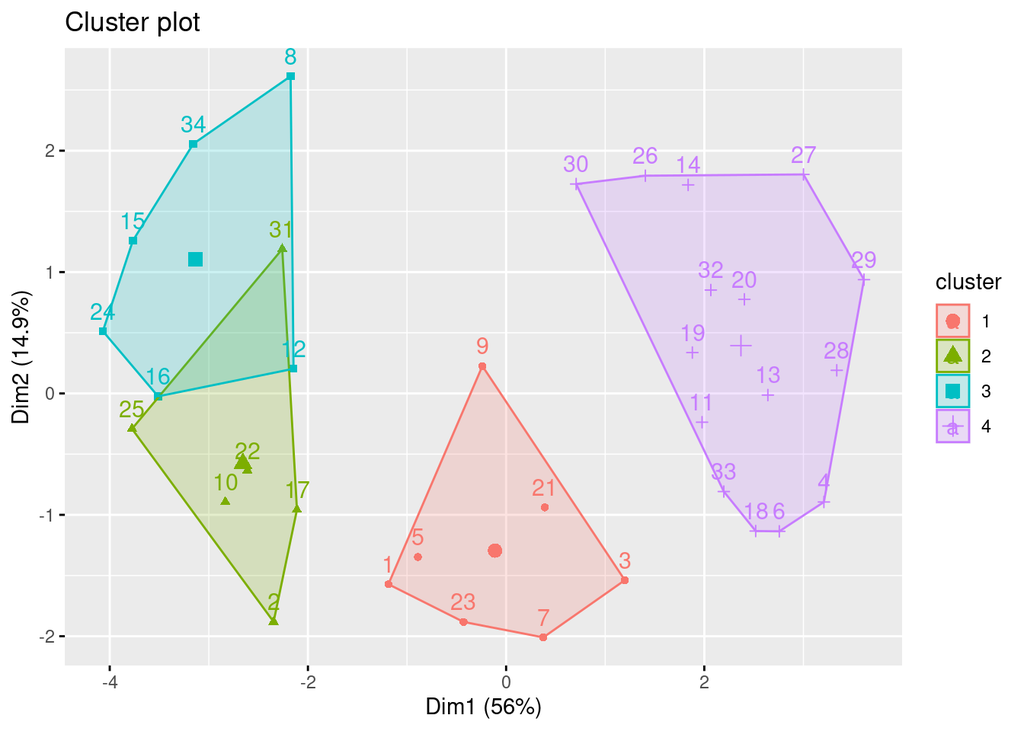

```r
fviz_cluster(k4,data=datos_pca)
```

## Buscando el número óptimo de clusters

Buscamos el número de clusters que maximice la similaridad intracluster y minimice la similaridad intercluster. Como kmeans recibe como argumento el número de clusters a realizar, debemos buscar nosotros cuál será el mejor número de clusters.

Para ello vamos a usar el Método de Silhouette, ya que se basa en la medida de calidad de agrupamiento Silhouette, que es ampliamente utilizada. El número óptimo de clusters según este enfoque es, de entre un rango de valores posibles para k, aquel que maximiza la silueta promedio.

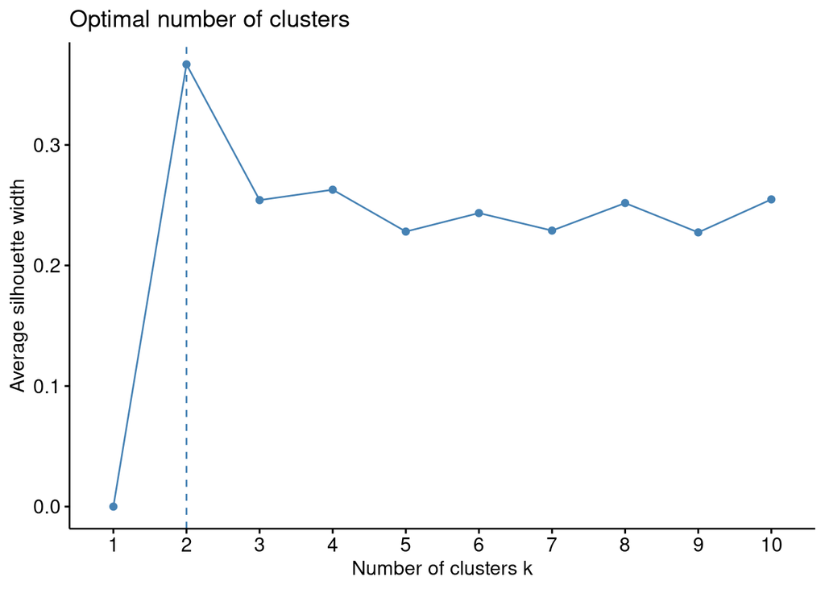

```r
set.seed(123)

fviz_nbclust(datos_pca, kmeans, method = "silhouette")
```

Vemos un pico considerable en el valor 2, lo que parece razonable ya que contamos con pocos datos. Repetimos ahora el clustering realizado antes fijando como número de clusters 2.

```r
k2 <- kmeans(datos_pca, centers = 2, nstart = 123)
str(k2)
```

```
## List of 9
##  $ cluster     : int [1:34] 2 2 1 1 2 1 1 2 2 2 ...
##  $ centers     : num [1:2, 1:11] 0.204 -0.23 -0.785 0.884 0.777 ...
##   ..- attr(*, "dimnames")=List of 2
##   .. ..$ : chr [1:2] "1" "2"
##   .. ..$ : chr [1:11] "ZPOBDENS" "ZTMINFAN" "ZESPVIDA" "ZPOBURB" ...
##  $ totss       : num 363
##  $ withinss    : num [1:2] 107.3 88.7
##  $ tot.withinss: num 196
##  $ betweenss   : num 167
##  $ size        : int [1:2] 18 16
##  $ iter        : int 1
##  $ ifault      : int 0
##  - attr(*, "class")= chr "kmeans"
```

```r
k2
```

```
## K-means clustering with 2 clusters of sizes 18, 16
##
## Cluster means:
##     ZPOBDENS   ZTMINFAN   ZESPVIDA    ZPOBURB   ZTMEDICO   ZPAGRICU    ZPSERVI
## 1  0.2043031 -0.7853941  0.7769316  0.7240592  0.7671309 -0.7448802  0.5956415
## 2 -0.2298410  0.8835684 -0.8740481 -0.8145666 -0.8630222  0.8379902 -0.6700966
##     ZTLIBROP   ZTEJERCI   ZTPOBACT   ZTENERGI
## 1  0.6366902  0.1499519  0.4474332  0.6725565
## 2 -0.7162765 -0.1686959 -0.5033623 -0.7566261
##
## Clustering vector:
##  [1] 2 2 1 1 2 1 1 2 2 2 1 2 1 1 2 2 2 1 1 1 1 2 2 2 2 1 1 1 1 1 2 1 1 2
##
## Within cluster sum of squares by cluster:
## [1] 107.32705  88.71239
##  (between_SS / total_SS =  46.0 %)
##
## Available components:
##
## [1] "cluster"      "centers"      "totss"        "withinss"     "tot.withinss"
## [6] "betweenss"    "size"         "iter"         "ifault"
```

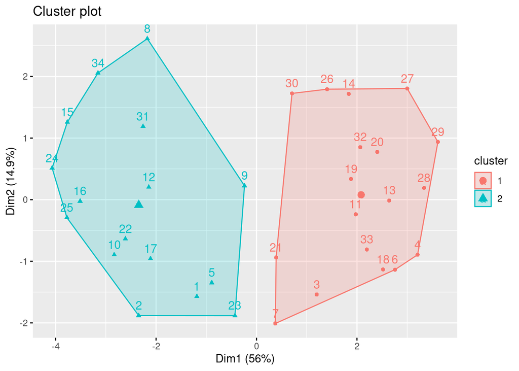

```r
fviz_cluster(k2,data=datos_pca)
```

Observamos al realizar esta agrupación dos clusters bien diferenciados, que no se solapan y de tamaños casi idénticos (18 y 16).

Además los centros no parecen demasiado influenciados por algún valor concreto (outlier). También destaca como las medias de las variables en cada cluster están muy diferenciadas, ya que en todas ellas una tiene media postiva y la otra negativa, de forma que se comprueba que en efecto los valores de cada variable (y más en conjunto) son muy diferentes entre los clusters.